# W3cubDocs

/GTK 3.24

# GtkMenu

GtkMenu — A menu widget

## Functions

| GtkWidget * | gtk_menu_new () |
| --- | --- |
| GtkWidget * | gtk_menu_new_from_model () |
| void | gtk_menu_set_screen () |
| void | gtk_menu_reorder_child () |
| void | gtk_menu_attach () |
| void | gtk_menu_popup_at_rect () |
| void | gtk_menu_popup_at_widget () |
| void | gtk_menu_popup_at_pointer () |
| void | gtk_menu_popup_for_device () |
| void | gtk_menu_popup () |
| void | gtk_menu_set_accel_group () |
| GtkAccelGroup * | gtk_menu_get_accel_group () |
| void | gtk_menu_set_accel_path () |
| const gchar * | gtk_menu_get_accel_path () |
| void | gtk_menu_set_title () |
| const gchar * | gtk_menu_get_title () |
| void | gtk_menu_set_monitor () |
| gint | gtk_menu_get_monitor () |
| void | gtk_menu_place_on_monitor () |
| gboolean | gtk_menu_get_tearoff_state () |
| void | gtk_menu_set_reserve_toggle_size () |
| gboolean | gtk_menu_get_reserve_toggle_size () |
| void | gtk_menu_popdown () |
| void | gtk_menu_reposition () |
| GtkWidget * | gtk_menu_get_active () |
| void | gtk_menu_set_active () |
| void | gtk_menu_set_tearoff_state () |
| void | gtk_menu_attach_to_widget () |
| void | gtk_menu_detach () |
| GtkWidget * | gtk_menu_get_attach_widget () |
| GList * | gtk_menu_get_for_attach_widget () |
| void | (*GtkMenuPositionFunc) () |
| void | (*GtkMenuDetachFunc) () |

## Properties

| GtkAccelGroup * | accel-group | Read / Write |
| --- | --- | --- |
| char * | accel-path | Read / Write |
| int | active | Read / Write |
| GdkAnchorHints | anchor-hints | Read / Write / Construct |
| GtkWidget * | attach-widget | Read / Write |
| GdkWindowTypeHint | menu-type-hint | Read / Write / Construct |
| int | monitor | Read / Write |
| int | rect-anchor-dx | Read / Write / Construct |
| int | rect-anchor-dy | Read / Write / Construct |
| gboolean | reserve-toggle-size | Read / Write |
| gboolean | tearoff-state | Read / Write |
| char * | tearoff-title | Read / Write |

## Child Properties

| int | bottom-attach | Read / Write |
| --- | --- | --- |
| int | left-attach | Read / Write |
| int | right-attach | Read / Write |
| int | top-attach | Read / Write |

## Style Properties

| GtkArrowPlacement | arrow-placement | Read |
| --- | --- | --- |
| float | arrow-scaling | Read |
| gboolean | double-arrows | Read |
| int | horizontal-offset | Read |
| int | horizontal-padding | Read |
| int | vertical-offset | Read |
| int | vertical-padding | Read |

## Signals

| void | move-scroll | Action |
| --- | --- | --- |
| void | popped-up | Run First |

## Types and Values

| struct | GtkMenu |
| --- | --- |
| enum | GtkArrowPlacement |

## Object Hierarchy

```
    GObject
    ╰── GInitiallyUnowned
        ╰── GtkWidget
            ╰── GtkContainer
                ╰── GtkMenuShell
                    ╰── GtkMenu
                        ╰── GtkRecentChooserMenu
```

## Implemented Interfaces

GtkMenu implements AtkImplementorIface and GtkBuildable.

## Includes

```
#include <gtk/gtk.h>
```

## Description

A GtkMenu is a GtkMenuShell that implements a drop down menu consisting of a list of GtkMenuItem objects which can be navigated and activated by the user to perform application functions.

A GtkMenu is most commonly dropped down by activating a GtkMenuItem in a GtkMenuBar or popped up by activating a GtkMenuItem in another GtkMenu.

A GtkMenu can also be popped up by activating a GtkComboBox. Other composite widgets such as the GtkNotebook can pop up a GtkMenu as well.

### CSS nodes

[output not shown]

The main CSS node of GtkMenu has name menu, and there are two subnodes with name arrow, for scrolling menu arrows. These subnodes get the .top and .bottom style classes.

## Functions

### gtk_menu_new ()

```
GtkWidget *
gtk_menu_new (void);
```

Creates a new GtkMenu

#### Returns

a new GtkMenu

### gtk_menu_new_from_model ()

```
GtkWidget *
gtk_menu_new_from_model (GMenuModel *model);
```

Creates a GtkMenu and populates it with menu items and submenus according to *`model`* .

The created menu items are connected to actions found in the GtkApplicationWindow to which the menu belongs - typically by means of being attached to a widget (see `gtk_menu_attach_to_widget()`) that is contained within the GtkApplicationWindows widget hierarchy.

Actions can also be added using `gtk_widget_insert_action_group()` on the menu's attach widget or on any of its parent widgets.

#### Parameters

| model | a GMenuModel |  |
| --- | --- | --- |

#### Returns

a new GtkMenu

Since: 3.4

### gtk_menu_set_screen ()

```
void
gtk_menu_set_screen (GtkMenu *menu,
                     GdkScreen *screen);
```

Sets the [GdkScreen](https://developer.gnome.org/gtk3/html/GdkScreen.html#GdkScreen-struct) on which the menu will be displayed.

#### Parameters

| menu | a GtkMenu |  |
| --- | --- | --- |
| screen | a [GdkScreen](https://developer.gnome.org/gtk3/html/GdkScreen.html#GdkScreen-struct), or `NULL` if the screen should be determined by the widget the menu is attached to. | [allow-none] |

Since: 2.2

### gtk_menu_reorder_child ()

```
void
gtk_menu_reorder_child (GtkMenu *menu,
                        GtkWidget *child,
                        gint position);
```

Moves *`child`* to a new *`position`* in the list of *`menu`* children.

#### Parameters

| menu | a GtkMenu |  |
| --- | --- | --- |
| child | the GtkMenuItem to move |  |
| position | the new position to place *`child`* . Positions are numbered from 0 to n - 1 |  |

### gtk_menu_attach ()

```
void
gtk_menu_attach (GtkMenu *menu,
                 GtkWidget *child,
                 guint left_attach,
                 guint right_attach,
                 guint top_attach,
                 guint bottom_attach);
```

Adds a new GtkMenuItem to a (table) menu. The number of “cells” that an item will occupy is specified by *`left_attach`* , *`right_attach`* , *`top_attach`* and *`bottom_attach`* . These each represent the leftmost, rightmost, uppermost and lower column and row numbers of the table. (Columns and rows are indexed from zero).

Note that this function is not related to `gtk_menu_detach()`.

#### Parameters

| menu | a GtkMenu |  |
| --- | --- | --- |
| child | a GtkMenuItem |  |
| left_attach | The column number to attach the left side of the item to |  |
| right_attach | The column number to attach the right side of the item to |  |
| top_attach | The row number to attach the top of the item to |  |
| bottom_attach | The row number to attach the bottom of the item to |  |

Since: 2.4

### gtk_menu_popup_at_rect ()

```
void
gtk_menu_popup_at_rect (GtkMenu *menu,
                        GdkWindow *rect_window,
                        const GdkRectangle *rect,
                        GdkGravity rect_anchor,
                        GdkGravity menu_anchor,
                        const GdkEvent *trigger_event);
```

Displays *`menu`* and makes it available for selection.

See `gtk_menu_popup_at_widget()` and `gtk_menu_popup_at_pointer()`, which handle more common cases for popping up menus.

*`menu`* will be positioned at *`rect`* , aligning their anchor points. *`rect`* is relative to the top-left corner of *`rect_window`* . *`rect_anchor`* and *`menu_anchor`* determine anchor points on *`rect`* and *`menu`* to pin together. *`menu`* can optionally be offset by “rect-anchor-dx” and “rect-anchor-dy”.

Anchors should be specified under the assumption that the text direction is left-to-right; they will be flipped horizontally automatically if the text direction is right-to-left.

Other properties that influence the behaviour of this function are “anchor-hints” and “menu-type-hint”. Connect to the “popped-up” signal to find out how it was actually positioned.

#### Parameters

| menu | the GtkMenu to pop up |  |
| --- | --- | --- |
| rect_window | the [GdkWindow](https://developer.gnome.org/gtk3/html/gdk3-Windows.html#GdkWindow-struct) *`rect`* is relative to. | [not nullable] |
| rect | the GdkRectangle to align *`menu`* with. | [not nullable] |
| rect_anchor | the point on *`rect`* to align with *`menu`* 's anchor point |  |
| menu_anchor | the point on *`menu`* to align with *`rect`* 's anchor point |  |
| trigger_event | the GdkEvent that initiated this request or `NULL` if it's the current event. | [nullable] |

Since: 3.22

### gtk_menu_popup_at_widget ()

```
void
gtk_menu_popup_at_widget (GtkMenu *menu,
                          GtkWidget *widget,
                          GdkGravity widget_anchor,
                          GdkGravity menu_anchor,
                          const GdkEvent *trigger_event);
```

Displays *`menu`* and makes it available for selection.

See `gtk_menu_popup_at_pointer()` to pop up a menu at the master pointer. `gtk_menu_popup_at_rect()` also allows you to position a menu at an arbitrary rectangle.

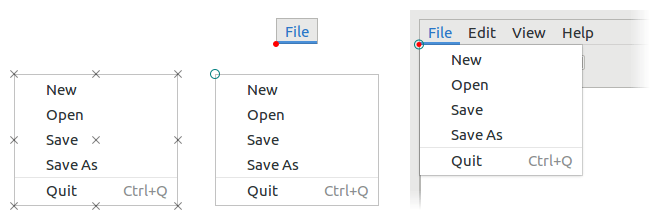

*`menu`* will be positioned at *`widget`* , aligning their anchor points. *`widget_anchor`* and *`menu_anchor`* determine anchor points on *`widget`* and *`menu`* to pin together. *`menu`* can optionally be offset by “rect-anchor-dx” and “rect-anchor-dy”.

Anchors should be specified under the assumption that the text direction is left-to-right; they will be flipped horizontally automatically if the text direction is right-to-left.

Other properties that influence the behaviour of this function are “anchor-hints” and “menu-type-hint”. Connect to the “popped-up” signal to find out how it was actually positioned.

#### Parameters

| menu | the GtkMenu to pop up |  |
| --- | --- | --- |
| widget | the GtkWidget to align *`menu`* with. | [not nullable] |
| widget_anchor | the point on *`widget`* to align with *`menu`* 's anchor point |  |
| menu_anchor | the point on *`menu`* to align with *`widget`* 's anchor point |  |
| trigger_event | the GdkEvent that initiated this request or `NULL` if it's the current event. | [nullable] |

Since: 3.22

### gtk_menu_popup_at_pointer ()

```
void
gtk_menu_popup_at_pointer (GtkMenu *menu,
                           const GdkEvent *trigger_event);
```

Displays *`menu`* and makes it available for selection.

See `gtk_menu_popup_at_widget()` to pop up a menu at a widget. `gtk_menu_popup_at_rect()` also allows you to position a menu at an arbitrary rectangle.

*`menu`* will be positioned at the pointer associated with *`trigger_event`* .

Properties that influence the behaviour of this function are “anchor-hints”, “rect-anchor-dx”, “rect-anchor-dy”, and “menu-type-hint”. Connect to the “popped-up” signal to find out how it was actually positioned.

#### Parameters

| menu | the GtkMenu to pop up |  |
| --- | --- | --- |
| trigger_event | the GdkEvent that initiated this request or `NULL` if it's the current event. | [nullable] |

Since: 3.22

### gtk_menu_popup_for_device ()

```
void
gtk_menu_popup_for_device (GtkMenu *menu,
                           GdkDevice *device,
                           GtkWidget *parent_menu_shell,
                           GtkWidget *parent_menu_item,
                           GtkMenuPositionFunc func,
                           gpointer data,
                           GDestroyNotify destroy,
                           guint button,
                           guint32 activate_time);
```

`gtk_menu_popup_for_device` has been deprecated since version 3.22 and should not be used in newly-written code.

Please use `gtk_menu_popup_at_widget()`, `gtk_menu_popup_at_pointer()`. or `gtk_menu_popup_at_rect()` instead

Displays a menu and makes it available for selection.

Applications can use this function to display context-sensitive menus, and will typically supply `NULL` for the *`parent_menu_shell`* , *`parent_menu_item`* , *`func`* , *`data`* and *`destroy`* parameters. The default menu positioning function will position the menu at the current position of *`device`* (or its corresponding pointer).

The *`button`* parameter should be the mouse button pressed to initiate the menu popup. If the menu popup was initiated by something other than a mouse button press, such as a mouse button release or a keypress, *`button`* should be 0.

The *`activate_time`* parameter is used to conflict-resolve initiation of concurrent requests for mouse/keyboard grab requests. To function properly, this needs to be the time stamp of the user event (such as a mouse click or key press) that caused the initiation of the popup. Only if no such event is available, `gtk_get_current_event_time()` can be used instead.

Note that this function does not work very well on GDK backends that do not have global coordinates, such as Wayland or Mir. You should probably use one of the gtk_menu_popup_at_ variants, which do not have this problem.

#### Parameters

| menu | a GtkMenu |  |
| --- | --- | --- |
| device | a [GdkDevice](https://developer.gnome.org/gtk3/html/GdkDevice.html#GdkDevice-struct). | [allow-none] |
| parent_menu_shell | the menu shell containing the triggering menu item, or `NULL`. | [allow-none] |
| parent_menu_item | the menu item whose activation triggered the popup, or `NULL`. | [allow-none] |
| func | a user supplied function used to position the menu, or `NULL`. | [allow-none] |
| data | user supplied data to be passed to *`func`* . | [allow-none] |
| destroy | destroy notify for *`data`* . | [allow-none] |
| button | the mouse button which was pressed to initiate the event |  |
| activate_time | the time at which the activation event occurred |  |

Since: 3.0

### gtk_menu_popup ()

```
void
gtk_menu_popup (GtkMenu *menu,
                GtkWidget *parent_menu_shell,
                GtkWidget *parent_menu_item,
                GtkMenuPositionFunc func,
                gpointer data,
                guint button,
                guint32 activate_time);
```

`gtk_menu_popup` has been deprecated since version 3.22 and should not be used in newly-written code.

Please use `gtk_menu_popup_at_widget()`, `gtk_menu_popup_at_pointer()`. or `gtk_menu_popup_at_rect()` instead

Displays a menu and makes it available for selection.

Applications can use this function to display context-sensitive menus, and will typically supply `NULL` for the *`parent_menu_shell`* , *`parent_menu_item`* , *`func`* and *`data`* parameters. The default menu positioning function will position the menu at the current mouse cursor position.

The *`button`* parameter should be the mouse button pressed to initiate the menu popup. If the menu popup was initiated by something other than a mouse button press, such as a mouse button release or a keypress, *`button`* should be 0.

The *`activate_time`* parameter is used to conflict-resolve initiation of concurrent requests for mouse/keyboard grab requests. To function properly, this needs to be the timestamp of the user event (such as a mouse click or key press) that caused the initiation of the popup. Only if no such event is available, `gtk_get_current_event_time()` can be used instead.

Note that this function does not work very well on GDK backends that do not have global coordinates, such as Wayland or Mir. You should probably use one of the gtk_menu_popup_at_ variants, which do not have this problem.

#### Parameters

| menu | a GtkMenu |  |
| --- | --- | --- |
| parent_menu_shell | the menu shell containing the triggering menu item, or `NULL`. | [allow-none] |
| parent_menu_item | the menu item whose activation triggered the popup, or `NULL`. | [allow-none] |
| func | a user supplied function used to position the menu, or `NULL`. | [scope async][allow-none] |
| data | user supplied data to be passed to *`func`* . |  |
| button | the mouse button which was pressed to initiate the event. |  |
| activate_time | the time at which the activation event occurred. |  |

### gtk_menu_set_accel_group ()

```
void
gtk_menu_set_accel_group (GtkMenu *menu,
                          GtkAccelGroup *accel_group);
```

Set the GtkAccelGroup which holds global accelerators for the menu. This accelerator group needs to also be added to all windows that this menu is being used in with `gtk_window_add_accel_group()`, in order for those windows to support all the accelerators contained in this group.

#### Parameters

| menu | a GtkMenu |  |
| --- | --- | --- |
| accel_group | the GtkAccelGroup to be associated with the menu. | [allow-none] |

### gtk_menu_get_accel_group ()

```
GtkAccelGroup *
gtk_menu_get_accel_group (GtkMenu *menu);
```

Gets the GtkAccelGroup which holds global accelerators for the menu. See `gtk_menu_set_accel_group()`.

#### Parameters

| menu | a GtkMenu |  |
| --- | --- | --- |

#### Returns

the GtkAccelGroup associated with the menu.

[transfer none]

### gtk_menu_set_accel_path ()

```
void
gtk_menu_set_accel_path (GtkMenu *menu,
                         const gchar *accel_path);
```

Sets an accelerator path for this menu from which accelerator paths for its immediate children, its menu items, can be constructed. The main purpose of this function is to spare the programmer the inconvenience of having to call `gtk_menu_item_set_accel_path()` on each menu item that should support runtime user changable accelerators. Instead, by just calling `gtk_menu_set_accel_path()` on their parent, each menu item of this menu, that contains a label describing its purpose, automatically gets an accel path assigned.

For example, a menu containing menu items “New” and “Exit”, will, after `gtk_menu_set_accel_path (menu, "&lt;Gnumeric-Sheet>/File");` has been called, assign its items the accel paths: `"&lt;Gnumeric-Sheet>/File/New"` and `"&lt;Gnumeric-Sheet>/File/Exit"`.

Assigning accel paths to menu items then enables the user to change their accelerators at runtime. More details about accelerator paths and their default setups can be found at `gtk_accel_map_add_entry()`.

Note that *`accel_path`* string will be stored in a GQuark. Therefore, if you pass a static string, you can save some memory by interning it first with `g_intern_static_string()`.

#### Parameters

| menu | a valid GtkMenu |  |
| --- | --- | --- |
| accel_path | a valid accelerator path, or `NULL` to unset the path. | [nullable] |

### gtk_menu_get_accel_path ()

```
const gchar *
gtk_menu_get_accel_path (GtkMenu *menu);
```

Retrieves the accelerator path set on the menu.

#### Parameters

| menu | a valid GtkMenu |  |
| --- | --- | --- |

#### Returns

the accelerator path set on the menu.

Since: 2.14

### gtk_menu_set_title ()

```
void
gtk_menu_set_title (GtkMenu *menu,
                    const gchar *title);
```

`gtk_menu_set_title` has been deprecated since version 3.10 and should not be used in newly-written code.

Sets the title string for the menu.

The title is displayed when the menu is shown as a tearoff menu. If *`title`* is `NULL`, the menu will see if it is attached to a parent menu item, and if so it will try to use the same text as that menu item’s label.

#### Parameters

| menu | a GtkMenu |  |
| --- | --- | --- |
| title | a string containing the title for the menu, or `NULL` to inherit the title of the parent menu item, if any. | [nullable] |

### gtk_menu_get_title ()

```
const gchar *
gtk_menu_get_title (GtkMenu *menu);
```

`gtk_menu_get_title` has been deprecated since version 3.10 and should not be used in newly-written code.

Returns the title of the menu. See `gtk_menu_set_title()`.

#### Parameters

| menu | a GtkMenu |  |
| --- | --- | --- |

#### Returns

the title of the menu, or `NULL` if the menu has no title set on it. This string is owned by GTK+ and should not be modified or freed.

### gtk_menu_set_monitor ()

```
void
gtk_menu_set_monitor (GtkMenu *menu,
                      gint monitor_num);
```

Informs GTK+ on which monitor a menu should be popped up. See [`gdk_monitor_get_geometry()`](https://developer.gnome.org/gtk3/html/GdkMonitor.html#gdk-monitor-get-geometry).

This function should be called from a GtkMenuPositionFunc if the menu should not appear on the same monitor as the pointer. This information can’t be reliably inferred from the coordinates returned by a GtkMenuPositionFunc, since, for very long menus, these coordinates may extend beyond the monitor boundaries or even the screen boundaries.

#### Parameters

| menu | a GtkMenu |  |
| --- | --- | --- |
| monitor_num | the number of the monitor on which the menu should be popped up |  |

Since: 2.4

### gtk_menu_get_monitor ()

```
gint
gtk_menu_get_monitor (GtkMenu *menu);
```

Retrieves the number of the monitor on which to show the menu.

#### Parameters

| menu | a GtkMenu |  |
| --- | --- | --- |

#### Returns

the number of the monitor on which the menu should be popped up or -1, if no monitor has been set

Since: 2.14

### gtk_menu_place_on_monitor ()

```
void
gtk_menu_place_on_monitor (GtkMenu *menu,
                           GdkMonitor *monitor);
```

Places *`menu`* on the given monitor.

#### Parameters

| menu | a GtkMenu |  |
| --- | --- | --- |
| monitor | the monitor to place the menu on |  |

Since: 3.22

### gtk_menu_get_tearoff_state ()

```
gboolean
gtk_menu_get_tearoff_state (GtkMenu *menu);
```

`gtk_menu_get_tearoff_state` has been deprecated since version 3.10 and should not be used in newly-written code.

Returns whether the menu is torn off. See `gtk_menu_set_tearoff_state()`.

#### Parameters

| menu | a GtkMenu |  |
| --- | --- | --- |

#### Returns

`TRUE` if the menu is currently torn off.

### gtk_menu_set_reserve_toggle_size ()

```
void
gtk_menu_set_reserve_toggle_size (GtkMenu *menu,
                                  gboolean reserve_toggle_size);
```

Sets whether the menu should reserve space for drawing toggles or icons, regardless of their actual presence.

#### Parameters

| menu | a GtkMenu |  |
| --- | --- | --- |
| reserve_toggle_size | whether to reserve size for toggles |  |

Since: 2.18

### gtk_menu_get_reserve_toggle_size ()

```
gboolean
gtk_menu_get_reserve_toggle_size (GtkMenu *menu);
```

Returns whether the menu reserves space for toggles and icons, regardless of their actual presence.

#### Parameters

| menu | a GtkMenu |  |
| --- | --- | --- |

#### Returns

Whether the menu reserves toggle space

Since: 2.18

### gtk_menu_popdown ()

```
void
gtk_menu_popdown (GtkMenu *menu);
```

Removes the menu from the screen.

#### Parameters

| menu | a GtkMenu |  |
| --- | --- | --- |

### gtk_menu_reposition ()

```
void
gtk_menu_reposition (GtkMenu *menu);
```

Repositions the menu according to its position function.

#### Parameters

| menu | a GtkMenu |  |
| --- | --- | --- |

### gtk_menu_get_active ()

```
GtkWidget *
gtk_menu_get_active (GtkMenu *menu);
```

Returns the selected menu item from the menu. This is used by the GtkComboBox.

#### Parameters

| menu | a GtkMenu |  |
| --- | --- | --- |

#### Returns

the GtkMenuItem that was last selected in the menu. If a selection has not yet been made, the first menu item is selected.

[transfer none]

### gtk_menu_set_active ()

```
void
gtk_menu_set_active (GtkMenu *menu,
                     guint index);
```

Selects the specified menu item within the menu. This is used by the GtkComboBox and should not be used by anyone else.

#### Parameters

| menu | a GtkMenu |  |
| --- | --- | --- |
| index | the index of the menu item to select. Index values are from 0 to n-1 |  |

### gtk_menu_set_tearoff_state ()

```
void
gtk_menu_set_tearoff_state (GtkMenu *menu,
                            gboolean torn_off);
```

`gtk_menu_set_tearoff_state` has been deprecated since version 3.10 and should not be used in newly-written code.

Changes the tearoff state of the menu. A menu is normally displayed as drop down menu which persists as long as the menu is active. It can also be displayed as a tearoff menu which persists until it is closed or reattached.

#### Parameters

| menu | a GtkMenu |  |
| --- | --- | --- |
| torn_off | If `TRUE`, menu is displayed as a tearoff menu. |  |

### gtk_menu_attach_to_widget ()

```
void
gtk_menu_attach_to_widget (GtkMenu *menu,
                           GtkWidget *attach_widget,
                           GtkMenuDetachFunc detacher);
```

Attaches the menu to the widget and provides a callback function that will be invoked when the menu calls `gtk_menu_detach()` during its destruction.

If the menu is attached to the widget then it will be destroyed when the widget is destroyed, as if it was a child widget. An attached menu will also move between screens correctly if the widgets moves between screens.

#### Parameters

| menu | a GtkMenu |  |
| --- | --- | --- |
| attach_widget | the GtkWidget that the menu will be attached to |  |
| detacher | the user supplied callback function that will be called when the menu calls `gtk_menu_detach()`. | [scope async][allow-none] |

### gtk_menu_detach ()

```
void
gtk_menu_detach (GtkMenu *menu);
```

Detaches the menu from the widget to which it had been attached. This function will call the callback function, *`detacher`* , provided when the `gtk_menu_attach_to_widget()` function was called.

#### Parameters

| menu | a GtkMenu |  |
| --- | --- | --- |

### gtk_menu_get_attach_widget ()

```
GtkWidget *
gtk_menu_get_attach_widget (GtkMenu *menu);
```

Returns the GtkWidget that the menu is attached to.

#### Parameters

| menu | a GtkMenu |  |
| --- | --- | --- |

#### Returns

the GtkWidget that the menu is attached to.

[transfer none]

### gtk_menu_get_for_attach_widget ()

```
GList *
gtk_menu_get_for_attach_widget (GtkWidget *widget);
```

Returns a list of the menus which are attached to this widget. This list is owned by GTK+ and must not be modified.

#### Parameters

| widget | a GtkWidget |  |
| --- | --- | --- |

#### Returns

the list of menus attached to his widget.

[element-type GtkWidget][transfer none]

Since: 2.6

### GtkMenuPositionFunc ()

```
void
(*GtkMenuPositionFunc) (GtkMenu *menu,
                        gint *x,
                        gint *y,
                        gboolean *push_in,
                        gpointer user_data);
```

A user function supplied when calling `gtk_menu_popup()` which controls the positioning of the menu when it is displayed. The function sets the *`x`* and *`y`* parameters to the coordinates where the menu is to be drawn. To make the menu appear on a different monitor than the mouse pointer, `gtk_menu_set_monitor()` must be called.

#### Parameters

[output not shown]

### GtkMenuDetachFunc ()

```
void
(*GtkMenuDetachFunc) (GtkWidget *attach_widget,
                      GtkMenu *menu);
```

A user function supplied when calling `gtk_menu_attach_to_widget()` which will be called when the menu is later detached from the widget.

#### Parameters

| attach_widget | the GtkWidget that the menu is being detached from. |  |
| --- | --- | --- |
| menu | the GtkMenu being detached. |  |

## Types and Values

### struct GtkMenu

```
struct GtkMenu;
```

### enum GtkArrowPlacement

Used to specify the placement of scroll arrows in scrolling menus.

#### Members

| GTK_ARROWS_BOTH | Place one arrow on each end of the menu. |  |
| --- | --- | --- |
| GTK_ARROWS_START | Place both arrows at the top of the menu. |  |
| GTK_ARROWS_END | Place both arrows at the bottom of the menu. |  |

## Property Details

### The `“accel-group”` property

```
  “accel-group”              GtkAccelGroup *
```

The accel group holding accelerators for the menu.

Owner: GtkMenu

Flags: Read / Write

Since: 2.14

### The `“accel-path”` property

```
  “accel-path”               char *
```

An accel path used to conveniently construct accel paths of child items.

Owner: GtkMenu

Flags: Read / Write

Default value: NULL

Since: 2.14

### The `“active”` property

```
  “active”                   int
```

The index of the currently selected menu item, or -1 if no menu item is selected.

Owner: GtkMenu

Flags: Read / Write

Allowed values: >= -1

Default value: -1

Since: 2.14

### The `“anchor-hints”` property

```
  “anchor-hints”             GdkAnchorHints
```

Positioning hints for aligning the menu relative to a rectangle.

These hints determine how the menu should be positioned in the case that the menu would fall off-screen if placed in its ideal position.

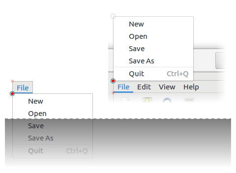

For example, [`GDK_ANCHOR_FLIP_Y`](https://developer.gnome.org/gtk3/html/gdk3-Windows.html#GDK-ANCHOR-FLIP-Y:CAPS) will replace [`GDK_GRAVITY_NORTH_WEST`](https://developer.gnome.org/gtk3/html/gdk3-Windows.html#GDK-GRAVITY-NORTH-WEST:CAPS) with [`GDK_GRAVITY_SOUTH_WEST`](https://developer.gnome.org/gtk3/html/gdk3-Windows.html#GDK-GRAVITY-SOUTH-WEST:CAPS) and vice versa if the menu extends beyond the bottom edge of the monitor.

See `gtk_menu_popup_at_rect()`, `gtk_menu_popup_at_widget()`, `gtk_menu_popup_at_pointer()`, “rect-anchor-dx”, “rect-anchor-dy”, “menu-type-hint”, and “popped-up”.

Owner: GtkMenu

Flags: Read / Write / Construct

Default value: GDK_ANCHOR_FLIP_X | GDK_ANCHOR_FLIP_Y | GDK_ANCHOR_SLIDE_X | GDK_ANCHOR_SLIDE_Y | GDK_ANCHOR_RESIZE_X | GDK_ANCHOR_RESIZE_Y

Since: 3.22

### The `“attach-widget”` property

```
  “attach-widget”            GtkWidget *
```

The widget the menu is attached to. Setting this property attaches the menu without a GtkMenuDetachFunc. If you need to use a detacher, use `gtk_menu_attach_to_widget()` directly.

Owner: GtkMenu

Flags: Read / Write

Since: 2.14

### The `“menu-type-hint”` property

```
  “menu-type-hint”           GdkWindowTypeHint
```

The GdkWindowTypeHint to use for the menu's [GdkWindow](https://developer.gnome.org/gtk3/html/gdk3-Windows.html#GdkWindow-struct).

See `gtk_menu_popup_at_rect()`, `gtk_menu_popup_at_widget()`, `gtk_menu_popup_at_pointer()`, “anchor-hints”, “rect-anchor-dx”, “rect-anchor-dy”, and “popped-up”.

Owner: GtkMenu

Flags: Read / Write / Construct

Default value: GDK_WINDOW_TYPE_HINT_POPUP_MENU

Since: 3.22

### The `“monitor”` property

```
  “monitor”                  int
```

The monitor the menu will be popped up on.

Owner: GtkMenu

Flags: Read / Write

Allowed values: >= -1

Default value: -1

Since: 2.14

### The `“rect-anchor-dx”` property

```
  “rect-anchor-dx”           int
```

Horizontal offset to apply to the menu, i.e. the rectangle or widget anchor.

See `gtk_menu_popup_at_rect()`, `gtk_menu_popup_at_widget()`, `gtk_menu_popup_at_pointer()`, “anchor-hints”, “rect-anchor-dy”, “menu-type-hint”, and “popped-up”.

Owner: GtkMenu

Flags: Read / Write / Construct

Default value: 0

Since: 3.22

### The `“rect-anchor-dy”` property

```
  “rect-anchor-dy”           int
```

Vertical offset to apply to the menu, i.e. the rectangle or widget anchor.

See `gtk_menu_popup_at_rect()`, `gtk_menu_popup_at_widget()`, `gtk_menu_popup_at_pointer()`, “anchor-hints”, “rect-anchor-dx”, “menu-type-hint”, and “popped-up”.

Owner: GtkMenu

Flags: Read / Write / Construct

Default value: 0

Since: 3.22

### The `“reserve-toggle-size”` property

```
  “reserve-toggle-size”      gboolean
```

A boolean that indicates whether the menu reserves space for toggles and icons, regardless of their actual presence.

This property should only be changed from its default value for special-purposes such as tabular menus. Regular menus that are connected to a menu bar or context menus should reserve toggle space for consistency.

Owner: GtkMenu

Flags: Read / Write

Default value: TRUE

Since: 2.18

### The `“tearoff-state”` property

```
  “tearoff-state”            gboolean
```

A boolean that indicates whether the menu is torn-off.

`GtkMenu:tearoff-state` has been deprecated since version 3.10 and should not be used in newly-written code.

Owner: GtkMenu

Flags: Read / Write

Default value: FALSE

Since: 2.6

### The `“tearoff-title”` property

```
  “tearoff-title”            char *
```

A title that may be displayed by the window manager when this menu is torn-off.

`GtkMenu:tearoff-title` has been deprecated since version 3.10 and should not be used in newly-written code.

Owner: GtkMenu

Flags: Read / Write

Default value: NULL

## Child Property Details

### The `“bottom-attach”` child property

```
  “bottom-attach”            int
```

The row number to attach the bottom of the child to.

Owner: GtkMenu

Flags: Read / Write

Allowed values: >= -1

Default value: -1

### The `“left-attach”` child property

```
  “left-attach”              int
```

The column number to attach the left side of the child to.

Owner: GtkMenu

Flags: Read / Write

Allowed values: >= -1

Default value: -1

### The `“right-attach”` child property

```
  “right-attach”             int
```

The column number to attach the right side of the child to.

Owner: GtkMenu

Flags: Read / Write

Allowed values: >= -1

Default value: -1

### The `“top-attach”` child property

```
  “top-attach”               int
```

The row number to attach the top of the child to.

Owner: GtkMenu

Flags: Read / Write

Allowed values: >= -1

Default value: -1

## Style Property Details

### The `“arrow-placement”` style property

```
  “arrow-placement”          GtkArrowPlacement
```

Indicates where scroll arrows should be placed.

`GtkMenu:arrow-placement` has been deprecated since version 3.20 and should not be used in newly-written code.

the value of this style property is ignored.

Owner: GtkMenu

Flags: Read

Default value: GTK_ARROWS_BOTH

Since: 2.16

### The `“arrow-scaling”` style property

```
  “arrow-scaling”            float
```

Arbitrary constant to scale down the size of the scroll arrow.

`GtkMenu:arrow-scaling` has been deprecated since version 3.20 and should not be used in newly-written code.

use the standard min-width/min-height CSS properties on the arrow node; the value of this style property is ignored.

Owner: GtkMenu

Flags: Read

Allowed values: [0,1]

Default value: 0.7

Since: 2.16

### The `“double-arrows”` style property

```
  “double-arrows”            gboolean
```

When `TRUE`, both arrows are shown when scrolling.

`GtkMenu:double-arrows` has been deprecated since version 3.20 and should not be used in newly-written code.

the value of this style property is ignored.

Owner: GtkMenu

Flags: Read

Default value: TRUE

### The `“horizontal-offset”` style property

```
  “horizontal-offset”        int
```

When the menu is a submenu, position it this number of pixels offset horizontally.

Owner: GtkMenu

Flags: Read

Default value: -2

### The `“horizontal-padding”` style property

```
  “horizontal-padding”       int
```

Extra space at the left and right edges of the menu.

`GtkMenu:horizontal-padding` has been deprecated since version 3.8 and should not be used in newly-written code.

use the standard padding CSS property (through objects like GtkStyleContext and GtkCssProvider); the value of this style property is ignored.

Owner: GtkMenu

Flags: Read

Allowed values: >= 0

Default value: 0

### The `“vertical-offset”` style property

```
  “vertical-offset”          int
```

When the menu is a submenu, position it this number of pixels offset vertically.

Owner: GtkMenu

Flags: Read

Default value: 0

### The `“vertical-padding”` style property

```
  “vertical-padding”         int
```

Extra space at the top and bottom of the menu.

`GtkMenu:vertical-padding` has been deprecated since version 3.8 and should not be used in newly-written code.

use the standard padding CSS property (through objects like GtkStyleContext and GtkCssProvider); the value of this style property is ignored.

Owner: GtkMenu

Flags: Read

Allowed values: >= 0

Default value: 1

## Signal Details

### The `“move-scroll”` signal

```
void
user_function (GtkMenu      *menu,
               GtkScrollType scroll_type,
               gpointer      user_data)
```

#### Parameters

| menu | a GtkMenu |  |
| --- | --- | --- |
| scroll_type | a GtkScrollType |  |
| user_data | user data set when the signal handler was connected. |  |

Flags: Action

### The `“popped-up”` signal

```
void
user_function (GtkMenu *menu,
               gpointer flipped_rect,
               gpointer final_rect,
               gboolean flipped_x,
               gboolean flipped_y,
               gpointer user_data)
```

Emitted when the position of *`menu`* is finalized after being popped up using `gtk_menu_popup_at_rect()`, `gtk_menu_popup_at_widget()`, or `gtk_menu_popup_at_pointer()`.

*`menu`* might be flipped over the anchor rectangle in order to keep it on-screen, in which case *`flipped_x`* and *`flipped_y`* will be set to `TRUE` accordingly.

*`flipped_rect`* is the ideal position of *`menu`* after any possible flipping, but before any possible sliding. *`final_rect`* is *`flipped_rect`* , but possibly translated in the case that flipping is still ineffective in keeping *`menu`* on-screen.

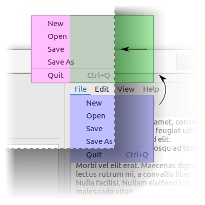

The blue menu is *`menu`* 's ideal position, the green menu is *`flipped_rect`* , and the red menu is *`final_rect`* .

See `gtk_menu_popup_at_rect()`, `gtk_menu_popup_at_widget()`, `gtk_menu_popup_at_pointer()`, “anchor-hints”, “rect-anchor-dx”, “rect-anchor-dy”, and “menu-type-hint”.

#### Parameters

| menu | the GtkMenu that popped up |  |
| --- | --- | --- |
| flipped_rect | the position of *`menu`* after any possible flipping or `NULL` if the backend can't obtain it. | [nullable] |
| final_rect | the final position of *`menu`* or `NULL` if the backend can't obtain it. | [nullable] |
| flipped_x | `TRUE` if the anchors were flipped horizontally |  |
| flipped_y | `TRUE` if the anchors were flipped vertically |  |
| user_data | user data set when the signal handler was connected. |  |

Flags: Run First

Since: 3.22

© 2005–2020 The GNOME Project  
Licensed under the GNU Lesser General Public License version 2.1 or later.  
https://developer.gnome.org/gtk3/3.24/GtkMenu.html